# PDF estimation using K-Nearest-Neighbors method (KNN).

Given a dataset, we can estimate its probability distribution function (PDF) using a method based on histograms. However, this straightforward and popular approach is often hampered by the choice of parameters. Hence, small changes on the histogram boundaries $[x_{min}, x_{max}]$ and the number of bins used can modify substantially the shape of the estimated PDF.

The KNN method requires only one parameter, the number of nearest neighbors. In this script, we investigate the performances of the KNN method with respect to the number of nearest neighbors and the number of data points.

## Reference probability-distribution function

We use a composite PDF that is the sum of a gaussian, an exponential and a triangular PDF:

> $P(x) = \alpha N(x|\mu, \sigma) + \beta Exp(x|\lambda) + (1-\alpha-\beta) Triangle(x|x_{low}, x_{mod}, x_{high})$

This is the reference PDF against which the estimated PDF are compared to.

N.B. We use 1-D datasets in this script; N-D datasets can be handled using similar metods extended to higher dimensions.

```python
print(__doc__)

# Author: Pierre Gravel <pierre.gravel@iid.ulaval.ca>
# License: BSD


%matplotlib inline

import numpy as np
import matplotlib.pyplot as plt

import math
from scipy.stats import expon, norm, triang
from sklearn.neighbors import NearestNeighbors

import seaborn as sns; sns.set()

# Used for reproductibility of the results
np.random.seed(42)
```

```
Automatically created module for IPython interactive environment
```

## A few improvement steps

The KNN estimator for PDF shares many similarities with the standard histogram-based and the Naive estimators. They all count the number of data points in successive bins in order to compute the local probability density $\hat P(x)$. The differences in them stem from the way these bins are defined.

### Standard histogram-based PDF

In this method, the bins are fixed and have the same width h. The probability density $\hat P(x)$ is proportional to the number of data points $x^{t}$ inside the bin centered at $x$

> $\hat P(x) = \large{\frac{\# \{x^{t}\}}{Nh}}$

There are as many $\hat P(x)$ values as there are bins.

### Naive PDF estimator

Instead of using juxtaposed bins of constant width h, the bin center now moves along the x axis with a width 2h.  
The probability density $\hat P(x)$ is proportional to the number of data points $x^{t}$ inside the interval $[x-h, x+h[$

> $\hat P(x) = \large{\frac{\# \{(x-h)\le x^{t}< x+h\}}{2Nh}} $

This estimator produces a finer-grained probability density $\hat P(x)$ because it is defined at every point x along the axis.

### K-nearest-neighors estimator

In this next improvement, both the bin center and the bin width vary along the x axis. The bin half width $h$ is redefined as

> $h(x) = D_{k}$

where $D_{k}$ is the distance from x to the $k^{th}$ nearest observation $x^{t}$. The number of observations in this interval is k. The expression of the estimator simplifies to

> $\hat P(x) = \large{\frac{k}{2ND_{k}}}$

All three expressions for $\hat P(x)$ are similar but their minor differences have major effects of the PDF.

# Part I: Dataset generation

In this section, we generate a dataset and compute an approximate histogram-based PDF from it. The goal is to make sure that the empirical PDF reproduces the model PDF. The dataset generation algorithm should then be trusted whatever the number of data points contained in a dataset.

Let us first define the dataset generation function:

```python
def generate_dataset(npts, prob_PDF, coeffs):
    # Number of data points in each distributon
    n = (npts*prob_PDF).astype(int)

    # Exponential component
    lam = coeffs[0]
    X1 = np.random.exponential(lam, size=n[0])

    # Gaussian component
    mu = coeffs[1]
    sigma = coeffs[2]
    X2 = np.random.normal(mu, sigma, size=n[1])

    # Triangular component
    left = coeffs[3]
    right = coeffs[4]
    c = coeffs[5]
    X3 =  left + (right-left)*triang.rvs(c, size=n[2])

    X = np.r_[X1, X2, X3]

    return X


def triangular_PDF(x, left, right, c):
    scale = right - left
    x_norm = (x-left)/scale

    pdf = triang(c).pdf(x_norm)/scale

    return pdf
```

Let us generate a dataset of 100K points and compare the PDF model with the empirical histogram-based PDF.

```python
# Parameters of the reference PDF
# Exponential component
lam = 5.

# Gaussian component
mu = 15.
sigma = 0.5

# Triangular component
left = 25.
mode = 33.
right = 35.
c = (mode-left)/(right-left)

coeffs = np.array([lam, mu, sigma, left, right, c])

# A priori probabilities of the three PDF components
alpha = 0.5
beta = 0.2
gamma = 1. - (alpha + beta)
prob_PDF = np.array([alpha, beta, gamma])
```

```python
# Dataset generation
npts = 100000
X = generate_dataset(npts, prob_PDF, coeffs)
```

The following figure shows a good agreement between the histogram-based and the model PDF.

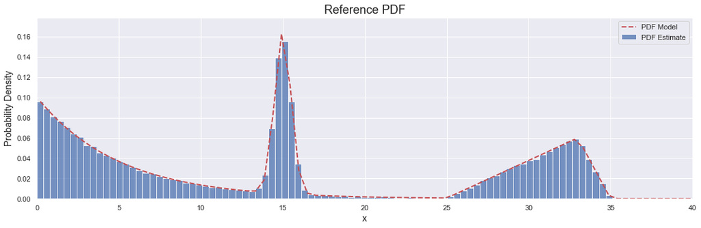

```python
fig, ax = plt.subplots(1,1,figsize=(15,5))

# ------- Empirical PDF ------
nbins = 130
hist, edges, patches = plt.hist(X, nbins, density=True, facecolor='b', alpha=0.75, label='PDF Estimate')

# Bins center positions
h = edges[1] - edges[0]
x = edges[:-1]+h/2.


# ------- Model PDF ------
xx = np.linspace(x.min(), x.max(), 100)
model = prob_PDF[0]*expon.pdf(xx, 0., lam) + prob_PDF[1]*norm.pdf(xx, mu, sigma) + \
        prob_PDF[2]*triangular_PDF(xx, left, right, c)
plt.plot(xx, model, ls="--", color='r', linewidth=2, label='PDF Model')


ax.set_xlabel('x', fontsize=14)
ax.set_ylabel('Probability Density', fontsize=14)
ax.set_title('Reference PDF', fontsize=18)
ax.legend(loc='upper right')

x_min = 0
x_max = 40
y_min = 0
y_max = 1.1*model.max()
ax.set_xlim([x_min, x_max]);
ax.set_ylim([y_min, y_max]);
fig.tight_layout()

plt.savefig('KNN_PDF_estimator_reference.png')
plt.savefig('KNN_PDF_estimator_reference.pdf')
```

## The K-Nearest-Neighbor PDF estimator

```python
def knn_estimator(k, xx, X):

    nbrs = NearestNeighbors(n_neighbors=k).fit(X.reshape(-1, 1))

    # Distances of the k-nearest neighbors to a position xx
    distances, indices = nbrs.kneighbors(xx.reshape(-1, 1))

    # Get the maximum distance; this is the value of Dk at position xx
    Dk = np.max(distances, axis=1)

    N = X.shape[0]
    p = k/(2*N*Dk)

    return p
```

## Properties of the K-Nearest-Neighbor PDF estimator

### Effect of the number of nearest neighbors (small dataset)

We use a small dataset to put the emphasis on the data points and their influence on the estimated PDF.

The first panel show the effect of single data points on the PDF; there is a spike at every data point. The next panels show that using more neighbors fuses the spikes and smooths out the PDF. However, using too many neighbors generates an overly smooth PDF.

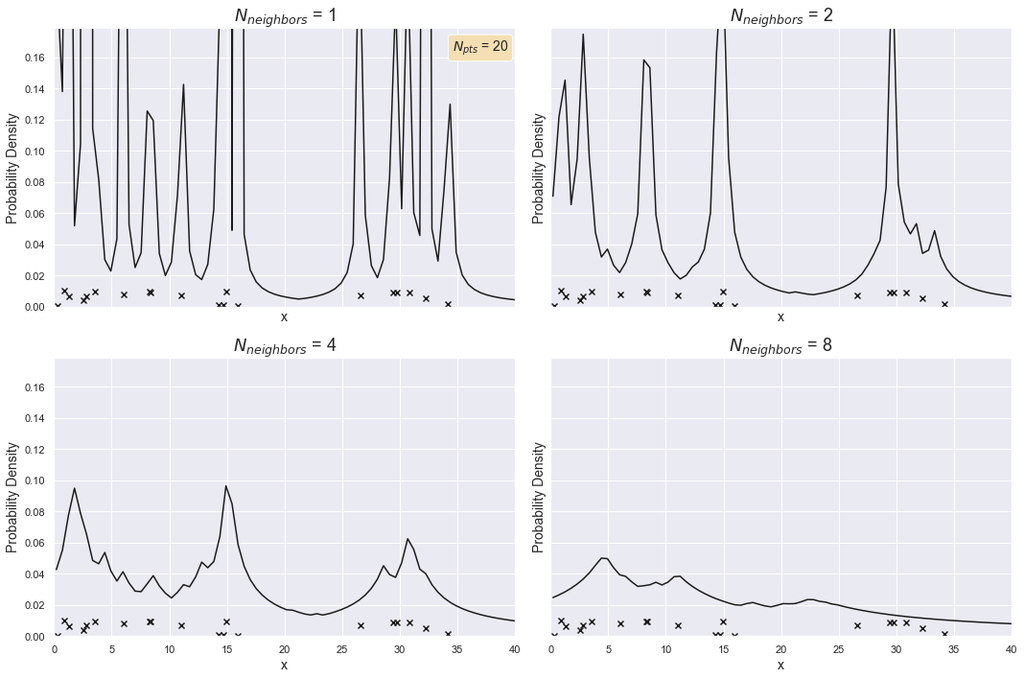

```python
# Dataset generation
npts = 20
X = generate_dataset(npts, prob_PDF, coeffs)

# Add some vertical jittering to the data points printed along the x axis for better visibility.
y0 = 0.01 * np.random.random(X.shape)

# Show PDF results for values of k= 1, 2, 4 and 8
fig, axs = plt.subplots(2, 2, figsize = (15,10), sharex=True, sharey=True)

for k,nNeighbors in enumerate([1, 2, 4, 8]):
    ax = axs.ravel()[k]

    pdf = knn_estimator(nNeighbors, xx, X)
    ax.plot(xx, pdf, ls='-', color='k')
    ax.scatter(X, y0, marker='x', color='k')

    if (k==0):
        text = r'$N_{pts}$' + ' = %d' % (npts)
        props = dict(boxstyle='round', facecolor='wheat', alpha=0.99)
        ax.text(37, 0.16, text, fontsize=14, horizontalalignment='center',
                      verticalalignment='bottom', bbox=props)


    ax.set_xlabel('x', fontsize=14)
    ax.set_ylabel('Probability Density', fontsize=14)
    ax.set_title('$N_{neighbors}$ = %d' % nNeighbors, fontsize=18)
    ax.set_xlim([x_min, x_max]);
    ax.set_ylim([y_min, y_max]);

fig.tight_layout()
plt.savefig('KNN_PDF_estimator_variable_NN_small_dataset.png')
plt.savefig('KNN_PDF_estimator_variable_NN_small_dataset.pdf')
```

## Effect of the number of nearest neighbors (large dataset)

What happens when the number of data points is much larger? In this situation, we can use more neighbors to refine the PDF measurements.

The new PDF estimates are more accurate as shown in the figure below. Increasing the number of neighbors improves the fit between the estimated PDF and the overlaid model PDF shown in red. Once again, using too many neighbors tend to overly smooth the results (last panel).

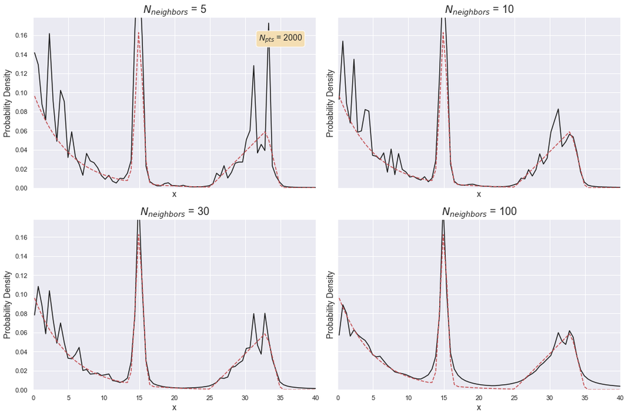

```python
# Dataset generation
npts = 2000
X = generate_dataset(npts, prob_PDF, coeffs)


fig, axs = plt.subplots(2, 2, figsize = (15,10), sharex=True, sharey=True)

for k,nNeighbors in enumerate([5, 10, 30, 100]):
    ax = axs.ravel()[k]

    pdf = knn_estimator(nNeighbors, xx, X)
    ax.plot(xx, pdf, ls='-', color='k')


    if (k==0):
        text = r'$N_{pts}$' + ' = %d' % (npts)
        props = dict(boxstyle='round', facecolor='wheat', alpha=0.99)
        ax.text(35, 0.15, text, fontsize=14, horizontalalignment='center',
                      verticalalignment='bottom', bbox=props)


    ax.plot(xx, model, ls="--", color="r")

    ax.set_xlabel('x', fontsize=14)
    ax.set_ylabel('Probability Density', fontsize=14)
    ax.set_title('$N_{neighbors}$ = %d' % nNeighbors, fontsize=18)
    ax.set_xlim([x_min, x_max]);
    ax.set_ylim([y_min, y_max]);

fig.tight_layout()
plt.savefig('KNN_PDF_estimator_variable_NN_large_dataset.png')
plt.savefig('KNN_PDF_estimator_variable_NN_large_dataset.pdf')
```

## Effect of the number of data points

What happens when we fix the number of nearest neighbors and increase the number of data points? As expected, the PDF estimates become more accurate. This is not very surprising as more information becomes available.

In the first panel, the data point distribution is sparse and the distance betwen a point x and its $40^{th}$ nearest neighbor is large. This leads to poor density estimation. Using more data points results in smaller $D_{40}$ values, narrower bins and better PDF estimates.

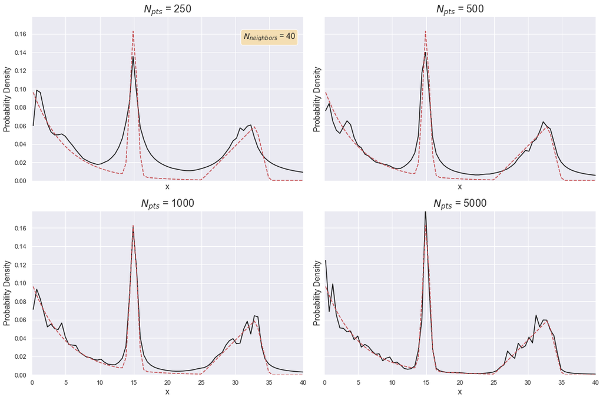

```python
nNeighbors = 40

fig, axs = plt.subplots(2, 2, figsize = (15,10), sharex=True, sharey=True)

for k,npts in enumerate([250, 500, 1000, 5000]):
    ax = axs.ravel()[k]

    # Dataset generation
    X = generate_dataset(npts, prob_PDF, coeffs)

    pdf = knn_estimator(nNeighbors, xx, X)
    ax.plot(xx, pdf, ls='-', color='k')

    if (k==0):
        text = r'$N_{neighbors}$' + ' = %d' % (nNeighbors)
        props = dict(boxstyle='round', facecolor='wheat', alpha=0.99)
        ax.text(35, 0.15, text, fontsize=14, horizontalalignment='center',
                      verticalalignment='bottom', bbox=props)


    ax.plot(xx, model, ls="--", color="r")

    ax.set_xlabel('x', fontsize=14)
    ax.set_ylabel('Probability Density', fontsize=14)
    ax.set_title('$N_{pts}$ = %d' % npts, fontsize=18)
    ax.set_xlim([x_min, x_max]);
    ax.set_ylim([y_min, y_max]);

fig.tight_layout()
plt.savefig('KNN_PDF_estimator_variable_dataset_size.png')
plt.savefig('KNN_PDF_estimator_variable_dataset_size.pdf')
```

## How do standard histogram and KNN methods compare?

### Example with a small dataset

The next figure shows the PDF results for the histogram-based and the KNN methods. The first method produces the best results in terms of accuracy and noise level.

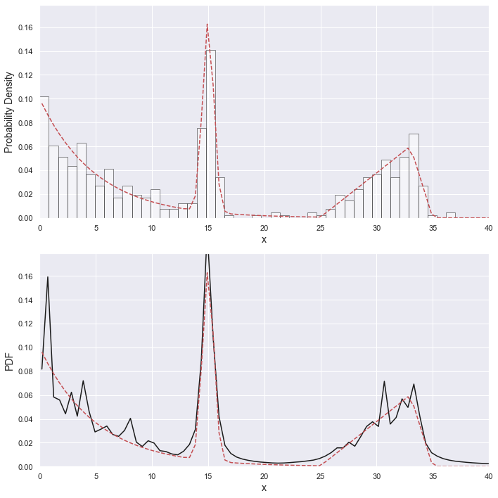

```python
# Dataset generation
npts = 500
X = generate_dataset(npts, prob_PDF, coeffs)

# Kernel-based method
nNeighbors = 15
pdf = knn_estimator(nNeighbors, xx, X)

fig, axs = plt.subplots(2, 1, figsize = (10,10))


# Histogram-based method
nbins = 50
axs[0].hist(X, nbins, density=True, facecolor='w', edgecolor='k', alpha=0.5)
axs[0].plot(xx, model, ls="--", color='r')
axs[0].set_xlabel('x', fontsize=14)
axs[0].set_ylabel('Probability Density', fontsize=14)
axs[0].set_xlim([x_min, x_max])
axs[0].set_ylim([y_min, y_max])


axs[1].plot(xx, pdf, ls='-', color='k')
axs[1].plot(xx, model, ls="--", color="r")
axs[1].set_xlabel('x', fontsize=14)
axs[1].set_ylabel('PDF', fontsize=14)
axs[1].set_xlim([x_min, x_max]);
axs[1].set_ylim([y_min, y_max]);
fig.tight_layout()

plt.savefig('KNN_Histogram_PDF_comparison_small_dataset.png')
plt.savefig('KNN_Histogram_PDF_comparison_small_dataset.pdf')
```

### Example with a large dataset

Once again, the histogram-based method produces the best results in terms of accuracy and noise level.

This being said, we should remember that the first method produces stepwise measurements of $P(x)$ with discontinuous boundaries whereas the KNN method produces more continuous results with an arbitrary spatial resolution.

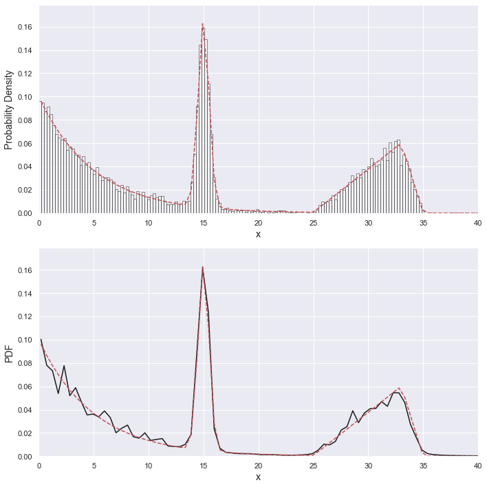

```python
# Dataset generation
npts = 10000
X = generate_dataset(npts, prob_PDF, coeffs)

# Kernel-based method
nNeighbors = 40
pdf = knn_estimator(nNeighbors, xx, X)

fig, axs = plt.subplots(2, 1, figsize = (10,10))


# Histogram-based method
nbins = 180
axs[0].hist(X, nbins, density=True, facecolor='w', edgecolor='k', alpha=0.5)
axs[0].plot(xx, model, ls="--", color='r')
axs[0].set_xlabel('x', fontsize=14)
axs[0].set_ylabel('Probability Density', fontsize=14)
axs[0].set_xlim([x_min, x_max])
axs[0].set_ylim([y_min, y_max])


axs[1].plot(xx, pdf, ls='-', color='k')
axs[1].plot(xx, model, ls="--", color="r")
axs[1].set_xlabel('x', fontsize=14)
axs[1].set_ylabel('PDF', fontsize=14)
axs[1].set_xlim([x_min, x_max]);
axs[1].set_ylim([y_min, y_max]);
fig.tight_layout()

plt.savefig('KNN_Histogram_PDF_comparison_large_dataset.png')
plt.savefig('KNN_Histogram_PDF_comparison_large_dataset.pdf')
```